# Max Tjen: 459 Homework 2

Max Tjen

2023-03-10

## 0.1 Setup

```r
library(nlme)
library(tidyverse)

theme_set(theme_bw())
```

## 0.2 Data Import

```r
pbc_data <- read_csv("/Users/mtjen/Desktop/459/homework/hw2/pbc.csv")

head(pbc_data)
```

```
# A tibble: 6 × 22
     id years status drug      age sex    year ascites hepat…¹ spiders
  <dbl> <dbl> <chr>  <chr>   <dbl> <chr> <dbl> <chr>   <chr>   <chr>
1     1  1.10 dead   D-peni…  58.8 fema… 0     Yes     Yes     Yes
2     1  1.10 dead   D-peni…  58.8 fema… 0.526 Yes     Yes     Yes
3     2 14.2  alive  D-peni…  56.4 fema… 0     No      Yes     Yes
4     2 14.2  alive  D-peni…  56.4 fema… 0.498 No      Yes     Yes
5     2 14.2  alive  D-peni…  56.4 fema… 0.999 No      Yes     Yes
6     2 14.2  alive  D-peni…  56.4 fema… 2.10  No      Yes     Yes
# … with 12 more variables: edema <chr>, serBilir <dbl>,
#   serChol <dbl>, albumin <dbl>, alkaline <dbl>, SGOT <dbl>,
#   platelets <dbl>, prothrombin <dbl>, histologic <dbl>,
#   status2 <dbl>, serBilirD <dbl>, serCholD <dbl>, and abbreviated
#   variable name ¹hepatomegaly
```

# 1 Question 1

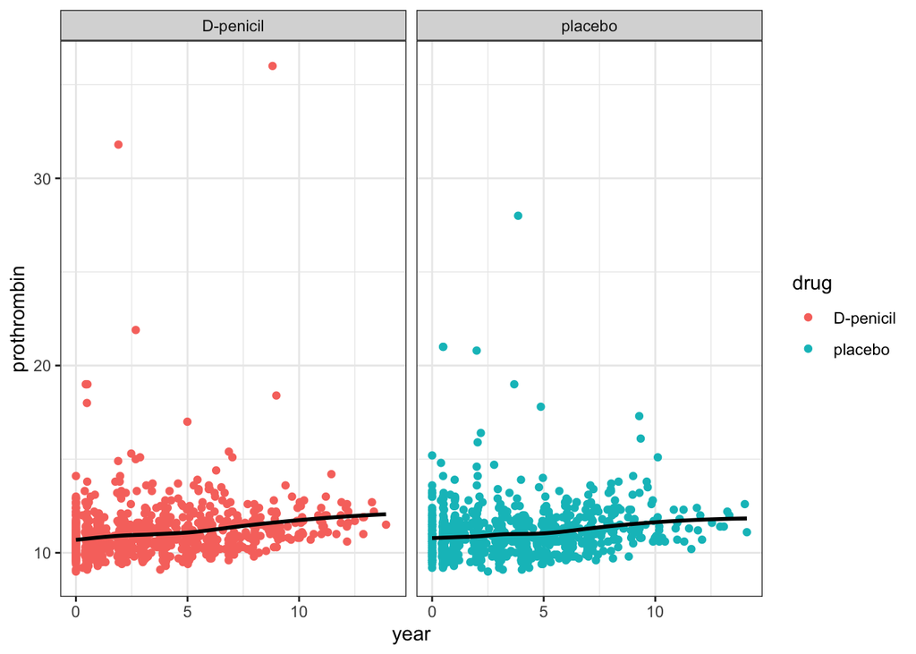

```r
q1_data <- pbc_data |>
  select(drug, year, prothrombin)

ggplot(pbc_data, aes(x = year, y = prothrombin, col = drug)) +
  geom_point() +
  geom_smooth(method = "loess", formula = y ~ x, se = FALSE, col = "black") +
  facet_grid(.~drug)
```

Our plot shows patient’s `prothrombin` values by `year` and is faceted by `drug`. This allows us to see the longitudinal relationship between `prothrombin` and `year` for each of the `drug` groups ‘D-penicil’ and ‘placebo’. By looking at this, it appears that the relationship for patients in each drug group is nearly the same in terms of the overall trend for each. Both of them appear to have a trend where `prothrombin` values steadily increase over time, albeit very little.

# 2 Question 2

```r
hw02_data <- pbc_data[pbc_data$prothrombin < 18,]

model <- gls(model = prothrombin ~ factor(drug) + year + factor(sex) + age,
             data = hw02_data,
             corr = corExp(form = ~ year|id),
             method = 'ML')

summary(model)
```

```
Generalized least squares fit by maximum likelihood
  Model: prothrombin ~ factor(drug) + year + factor(sex) + age
  Data: hw02_data
       AIC      BIC    logLik
  4801.692 4840.656 -2393.846

Correlation Structure: Exponential spatial correlation
 Formula: ~year | id
 Parameter estimate(s):
   range
1.841455

Coefficients:
                       Value  Std.Error  t-value p-value
(Intercept)         9.962010 0.21474057 46.39091  0.0000
factor(drug)placebo 0.105021 0.08079287  1.29988  0.1938
year                0.113872 0.01122225 10.14699  0.0000
factor(sex)male     0.334063 0.12546166  2.66267  0.0078
age                 0.012503 0.00400793  3.11962  0.0018

 Correlation:
                    (Intr) fctr(d) year   fctr(s)
factor(drug)placebo -0.315
year                -0.218  0.008
factor(sex)male      0.078  0.018  -0.028
age                 -0.949  0.137   0.060 -0.158

Standardized residuals:
       Min         Q1        Med         Q3        Max
-2.2517738 -0.7566164 -0.2421855  0.3409895  5.9238773

Residual standard error: 1.050333
Degrees of freedom: 1932 total; 1927 residual
```

Here, we create a general linear model to compare the longitudinal response in `year` between `prothrombin` and `drug`. We also adjust the model for gender and age.

# 3 Question 3

Based on the fit model and the fact that `prothrombin` represents standardized blood clotting time in seconds, we can interpret the coefficient meanings. For (drug)placebo, the coefficient is 0.105 with a p-value of 0.194. This means that if a patient is given the placebo rather than D-penicil, their standardized blood clotting time is expected to increase by 0.105 This coefficient is also determined to be insignificant for 95% significance, as it is above both the threshold of 0.05. `year` is the next variable with a coefficient of 0.114 and a p-value of 0.000. This means that standardized blood clotting time is expected to increase by 0.114 for each additional year from the enrollment date to the current date. The p-value is also below the threshold of 0.05, which means that it’s significant with 95% significance. The next coefficient is for (sex)male, which has a coefficient of 0.334 and p-value of 0.008 and represents if a patient is male or female. This means that if a patient is male, then their standardized blood clotting time is expected to increase by 0.334 This coefficient is also determined to be significant for 95% significance, as it is below both the threshold of 0.05. The last coefficient is `age`, which represents the patient’s age at registration in years. `age` has a coefficient of 0.013 and a p-value of 0.002, meaning that for each additional year old a patient is when they enrolled, their standardized blood clotting time is expected to increase by 0.013. This coefficient is also determined to be significant for 95% significance, as it is below both the threshold of 0.05.

# 4 Question 4

## 4.1 Hypotheses

```r
# model to test hypothesis
model4 <- gls(model = prothrombin ~ factor(drug) * year,
             data = hw02_data,
             corr = corExp(form = ~ year|id),
             method = 'ML')
```

## 4.2 Wald Test

```r
beta.hat <- coef(model4)
h <- c(0)
L <- rbind(c(0, 0, 0, 1))

v.beta.hat <- model4$varBeta
l.beta.hat <- L %*% beta.hat

# wald stat and p value
wald <- t(l.beta.hat - h) %*% solve(L %*% v.beta.hat %*% t(L)) %*% (l.beta.hat - h)
pVal <- 1 - pchisq(wald, df = 1)

wald
```

```
          [,1]
[1,] 0.2879632
```

```r
pVal
```

```
          [,1]
[1,] 0.5915287
```

By running the Wald test, we can see that the Wald statistic is 0.288 and its p-value is 0.592. Because the p-value is greater than 0.05, we can’t conclude that we should reject the null hypothesis.

## 4.3 Likelihood Ratio Test

```r
# reduced model
model4_red <- gls(model = prothrombin ~ factor(drug) + year,
                  data = hw02_data,
                  corr = corExp(form = ~ year|id),
                  method = 'ML')

# log likelihood for each model
l2 <- model4$logLik
l1 <- model4_red$logLik
ts <- -2 * (l1 - l2)

p.value.alt <- 1 - pchisq(ts, df = 1)
anova(model4, model4_red)
```

```
           Model df      AIC      BIC    logLik   Test   L.Ratio
model4         1  6 4819.047 4852.445 -2403.524
model4_red     2  5 4817.336 4845.167 -2403.668 1 vs 2 0.2884414
           p-value
model4
model4_red  0.5912
```

```r
p.value.alt
```

```
[1] 0.591221
```

Here, we run the likelihood ratio test and we can see that the p-value is nearly identical to that of the Wald test, so we can’t reject the null hypothesis again.

## 4.4 Comparison

```r
anova(model4)
```

```
Denom. DF: 1928
                  numDF  F-value p-value
(Intercept)           1 72933.65  <.0001
factor(drug)          1     0.55  0.4575
year                  1    99.15  <.0001
factor(drug):year     1     0.29  0.5916
```

From the ANOVA test, we ca see that the p-value for the interaction term is also very similar to the p-values for both the Wald test and the Likelihood Ratio test. Based on all of these tests, the null hypothesis can’t be rejected, which means that $\beta_3$ = 0. Since $\beta_3$ represents the interaction term, we can conclude that the longitudinal trends in prothrombin are similar between the two treatment groups.

# 5 Question 5

## 5.1 Part 1

```r
# original model
model5 <- gls(model = prothrombin ~ factor(drug) + year + factor(sex) + age,
             data = hw02_data,
             corr = corExp(form = ~ year|id),
             method = 'REML')

summary(model5)
```

```
Generalized least squares fit by REML
  Model: prothrombin ~ factor(drug) + year + factor(sex) + age
  Data: hw02_data
       AIC     BIC    logLik
  4828.174 4867.12 -2407.087

Correlation Structure: Exponential spatial correlation
 Formula: ~year | id
 Parameter estimate(s):
   range
1.861604

Coefficients:
                       Value  Std.Error  t-value p-value
(Intercept)         9.960551 0.21589693 46.13568  0.0000
factor(drug)placebo 0.105340 0.08124494  1.29657  0.1949
year                0.114193 0.01126680 10.13540  0.0000
factor(sex)male     0.334088 0.12617816  2.64775  0.0082
age                 0.012533 0.00402981  3.10996  0.0019

 Correlation:
                    (Intr) fctr(d) year   fctr(s)
factor(drug)placebo -0.315
year                -0.218  0.008
factor(sex)male      0.078  0.018  -0.028
age                 -0.949  0.137   0.060 -0.158

Standardized residuals:
       Min         Q1        Med         Q3        Max
-2.2441524 -0.7537027 -0.2420331  0.3393816  5.8980255

Residual standard error: 1.054613
Degrees of freedom: 1932 total; 1927 residual
```

```r
model51 <- gls(model = prothrombin ~ factor(drug) + year + factor(sex) + age,
             data = hw02_data,
             corr = corExp(form = ~ year|id),
             weights = varExp(0.5, form = ~year),
             method = 'REML')

summary(model51)
```

```
Generalized least squares fit by REML
  Model: prothrombin ~ factor(drug) + year + factor(sex) + age
  Data: hw02_data
       AIC      BIC    logLik
  4827.589 4872.099 -2405.795

Correlation Structure: Exponential spatial correlation
 Formula: ~year | id
 Parameter estimate(s):
   range
1.904325
Variance function:
 Structure: Exponential of variance covariate
 Formula: ~year
 Parameter estimates:
      expon
-0.00897931

Coefficients:
                       Value  Std.Error  t-value p-value
(Intercept)         9.960670 0.21889051 45.50526  0.0000
factor(drug)placebo 0.102519 0.08208166  1.24899  0.2118
year                0.114798 0.01104186 10.39658  0.0000
factor(sex)male     0.335559 0.12722897  2.63744  0.0084
age                 0.012533 0.00408128  3.07086  0.0022

 Correlation:
                    (Intr) fctr(d) year   fctr(s)
factor(drug)placebo -0.314
year                -0.226  0.008
factor(sex)male      0.075  0.017  -0.030
age                 -0.948  0.137   0.063 -0.154

Standardized residuals:
       Min         Q1        Med         Q3        Max
-2.2515493 -0.7499045 -0.2420694  0.3342611  5.9579970

Residual standard error: 1.090367
Degrees of freedom: 1932 total; 1927 residual
```

## 5.2 Part 2

```r
model52 <- gls(model = prothrombin ~ factor(drug) + year + factor(sex) + age,
             data = hw02_data,
             corr = corExp(form = ~ year|id),
             weights = varExp(0.5, form = ~year|drug),
             method = 'REML')

summary(model52)
```

```
Generalized least squares fit by REML
  Model: prothrombin ~ factor(drug) + year + factor(sex) + age
  Data: hw02_data
       AIC      BIC    logLik
  4817.484 4867.558 -2399.742

Correlation Structure: Exponential spatial correlation
 Formula: ~year | id
 Parameter estimate(s):
   range
1.924984
Variance function:
 Structure: Exponential of variance covariate, different strata
 Formula: ~year | drug
 Parameter estimates:
   D-penicil      placebo
-0.023058588  0.002939443

Coefficients:
                       Value  Std.Error  t-value p-value
(Intercept)         9.960492 0.21769315 45.75473  0.0000
factor(drug)placebo 0.107667 0.08267244  1.30233  0.1930
year                0.115390 0.01092359 10.56337  0.0000
factor(sex)male     0.341931 0.12657358  2.70144  0.0070
age                 0.012496 0.00405018  3.08523  0.0021

 Correlation:
                    (Intr) fctr(d) year   fctr(s)
factor(drug)placebo -0.313
year                -0.247  0.096
factor(sex)male      0.063  0.019  -0.028
age                 -0.947  0.135   0.068 -0.142

Standardized residuals:
       Min         Q1        Med         Q3        Max
-2.1727239 -0.7454657 -0.2432498  0.3303105  5.9232177

Residual standard error: 1.094767
Degrees of freedom: 1932 total; 1927 residual
```